# Bank Churn Prediction with DNN

### Background:

Businesses like banks that provide service have to worry about the problem of 'Churn' i.e. customers leaving and joining another service provider. It is important to understand which aspects of the service influence a customer's decision in this regard. Management can concentrate efforts on the improvement of service, keeping in mind these priorities.

### Objective:

To build a neural network-based classifier that can determine whether customers will leave or not in the next 6 months.

#### Data Description:

- Data is of various customers of a bank with their credit limit, the total number of credit cards the customer has, and different channels through which customer has contacted the bank for any queries, different channels include visiting the bank, online and through a call centre.
- RowNumber: Row number.
- CustomerId: Unique identification key for different customers.
- Surname: Surname of the customer
- Credit Score: Credit score is a measure of an individual's ability to pay back the borrowed amount. It is the numerical representation of their creditworthiness. A credit score is a 3-digit number that falls in the range of 300-900, 900 being the highest.
- Geography: The country to which the customer belongs.
- Gender: The gender of the customer.
- Age: Age of the customer.
- Tenure: The period of time a customer has been associated with the bank.
- Balance: The account balance (the amount of money deposited in the bank account) of the customer.
- NumOfProducts: How many accounts, bank account affiliated products the person has.
- HasCrCard: Does the customer have a credit card through the bank?
- IsActiveMember: Subjective, but for the concept
- EstimatedSalary: Estimated salary of the customer.
- **Exited**: Did they leave the bank after all? **Target variable.**

```python
import tensorflow as tf
print(tf.__version__)
```

```
2.0.0
```

```python
import pandas as pd
import numpy as np
import seaborn as sns
%matplotlib inline

from sklearn.model_selection import train_test_split
import tensorflow as tf
from sklearn import preprocessing
from tensorflow.keras.models import Sequential
from tensorflow.keras.layers import Dense, Dropout, BatchNormalization
from sklearn.metrics import accuracy_score, confusion_matrix, precision_score, recall_score, f1_score, precision_recall_curve, auc
import matplotlib.pyplot as plt
from tensorflow.keras import optimizers
```

```python
df=pd.read_csv('bank.csv')
df.head()
```

|  | RowNumber | CustomerId | Surname | CreditScore | Geography | Gender | Age | Tenure | Balance | NumOfProducts | HasCrCard | IsActiveMember | EstimatedSalary | Exited |
| --- | --- | --- | --- | --- | --- | --- | --- | --- | --- | --- | --- | --- | --- | --- |
| 0 | 1 | 15634602 | Hargrave | 619 | France | Female | 42 | 2 | 0.00 | 1 | 1 | 1 | 101348.88 | 1 |
| 1 | 2 | 15647311 | Hill | 608 | Spain | Female | 41 | 1 | 83807.86 | 1 | 0 | 1 | 112542.58 | 0 |
| 2 | 3 | 15619304 | Onio | 502 | France | Female | 42 | 8 | 159660.80 | 3 | 1 | 0 | 113931.57 | 1 |
| 3 | 4 | 15701354 | Boni | 699 | France | Female | 39 | 1 | 0.00 | 2 | 0 | 0 | 93826.63 | 0 |
| 4 | 5 | 15737888 | Mitchell | 850 | Spain | Female | 43 | 2 | 125510.82 | 1 | 1 | 1 | 79084.10 | 0 |

```python
df.shape
```

```
(10000, 14)
```

```python
df.info()
```

```
<class 'pandas.core.frame.DataFrame'>
RangeIndex: 10000 entries, 0 to 9999
Data columns (total 14 columns):
 #   Column           Non-Null Count  Dtype
---  ------           --------------  -----
 0   RowNumber        10000 non-null  int64
 1   CustomerId       10000 non-null  int64
 2   Surname          10000 non-null  object
 3   CreditScore      10000 non-null  int64
 4   Geography        10000 non-null  object
 5   Gender           10000 non-null  object
 6   Age              10000 non-null  int64
 7   Tenure           10000 non-null  int64
 8   Balance          10000 non-null  float64
 9   NumOfProducts    10000 non-null  int64
 10  HasCrCard        10000 non-null  int64
 11  IsActiveMember   10000 non-null  int64
 12  EstimatedSalary  10000 non-null  float64
 13  Exited           10000 non-null  int64
dtypes: float64(2), int64(9), object(3)
memory usage: 1.1+ MB
```

### Univariate EDA

```python
df.isna().sum()
```

```
RowNumber          0
CustomerId         0
Surname            0
CreditScore        0
Geography          0
Gender             0
Age                0
Tenure             0
Balance            0
NumOfProducts      0
HasCrCard          0
IsActiveMember     0
EstimatedSalary    0
Exited             0
dtype: int64
```

```python
df.nunique()
```

```
RowNumber          10000
CustomerId         10000
Surname             2932
CreditScore          460
Geography              3
Gender                 2
Age                   70
Tenure                11
Balance             6382
NumOfProducts          4
HasCrCard              2
IsActiveMember         2
EstimatedSalary     9999
Exited                 2
dtype: int64
```

```python
df.describe().T
```

|  | count | mean | std | min | 25% | 50% | 75% | max |
| --- | --- | --- | --- | --- | --- | --- | --- | --- |
| RowNumber | 10000.0 | 5.000500e+03 | 2886.895680 | 1.00 | 2500.75 | 5.000500e+03 | 7.500250e+03 | 10000.00 |
| CustomerId | 10000.0 | 1.569094e+07 | 71936.186123 | 15565701.00 | 15628528.25 | 1.569074e+07 | 1.575323e+07 | 15815690.00 |
| CreditScore | 10000.0 | 6.505288e+02 | 96.653299 | 350.00 | 584.00 | 6.520000e+02 | 7.180000e+02 | 850.00 |
| Age | 10000.0 | 3.892180e+01 | 10.487806 | 18.00 | 32.00 | 3.700000e+01 | 4.400000e+01 | 92.00 |
| Tenure | 10000.0 | 5.012800e+00 | 2.892174 | 0.00 | 3.00 | 5.000000e+00 | 7.000000e+00 | 10.00 |
| Balance | 10000.0 | 7.648589e+04 | 62397.405202 | 0.00 | 0.00 | 9.719854e+04 | 1.276442e+05 | 250898.09 |
| NumOfProducts | 10000.0 | 1.530200e+00 | 0.581654 | 1.00 | 1.00 | 1.000000e+00 | 2.000000e+00 | 4.00 |
| HasCrCard | 10000.0 | 7.055000e-01 | 0.455840 | 0.00 | 0.00 | 1.000000e+00 | 1.000000e+00 | 1.00 |
| IsActiveMember | 10000.0 | 5.151000e-01 | 0.499797 | 0.00 | 0.00 | 1.000000e+00 | 1.000000e+00 | 1.00 |
| EstimatedSalary | 10000.0 | 1.000902e+05 | 57510.492818 | 11.58 | 51002.11 | 1.001939e+05 | 1.493882e+05 | 199992.48 |
| Exited | 10000.0 | 2.037000e-01 | 0.402769 | 0.00 | 0.00 | 0.000000e+00 | 0.000000e+00 | 1.00 |

```python
df['Surname'].value_counts()[0:20]
```

```
Smith       32
Scott       29
Martin      29
Walker      28
Brown       26
Genovese    25
Shih        25
Yeh         25
Maclean     24
Wright      24
White       23
Wilson      23
Ma          23
Fanucci     23
Johnson     22
Moore       22
Wang        22
Chu         22
Lu          22
McGregor    21
Name: Surname, dtype: int64
```

`Checking duplicates`

```python
dups = df.duplicated()
print('Number of duplicate rows = %d' % (dups.sum()))

df[dups]
```

```
Number of duplicate rows = 0
```

|  | RowNumber | CustomerId | Surname | CreditScore | Geography | Gender | Age | Tenure | Balance | NumOfProducts | HasCrCard | IsActiveMember | EstimatedSalary | Exited |
| --- | --- | --- | --- | --- | --- | --- | --- | --- | --- | --- | --- | --- | --- | --- |

```python
df['Surname'].duplicated().sum()
```

```
7068
```

```python
df['Exited'].value_counts(normalize=True)*100
```

```
0    79.63
1    20.37
Name: Exited, dtype: float64
```

### Insights:

- All numerical data, except of 'Surname', 'Geography' and 'Gender'
- No NaN or missing values
- Columns 'HasCrCard', 'IsActiveMember', and target 'Exited' already encoded as 0 and 1 as intergers
- Inbalanced columns are 'Balance', 'NumOfProducts' and target 'Exited'
- Only about 20% of the target 'Exited' did exited (to concentrate on for modeling)
- Smiths are the most common!
- Unique columns for all users are: 'RowNumber' and 'CustomerId'. 'Surname' is non-unique, although cannot be related to the analysis as being simpy a name.
- Scaling is must due to very large values of some variables ('Balance, 'CreditScore') vs. others.

### Dropping unique columns for all users and not-related

```python
# SI_No and Customer Key columns is to identify rows and customers ID, hence can be skipped in analysis

df1=df.drop(['RowNumber', 'CustomerId', 'Surname'], axis=1)
```

### Bivariate EDA

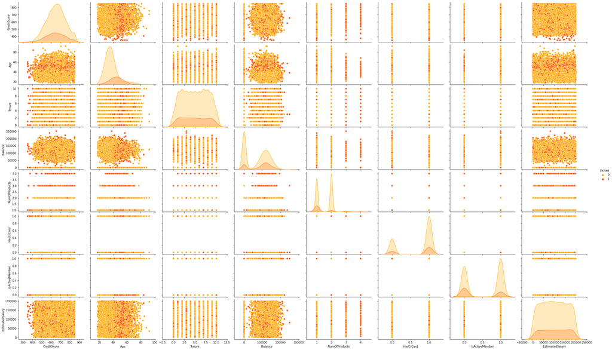

```python
#importing seaborn for statistical plots
sns.pairplot(df1, hue='Exited', height=2.2, aspect=1.7, palette='autumn_r')
```

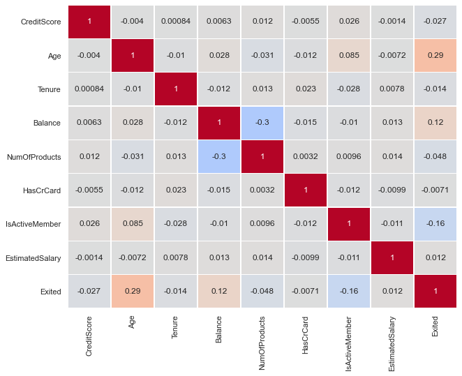

```python
# Correlations heat map

sns.set(rc={'figure.figsize':(10, 8)})
sns.heatmap(df1.corr(),
            annot=True,
            linewidths=0.5,
            center=0,
            cbar=False,
            cmap="coolwarm")
plt.show()
```

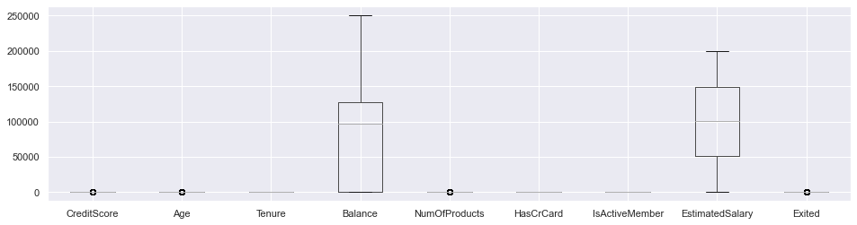

```python
df1.boxplot(figsize=(16,4))
```

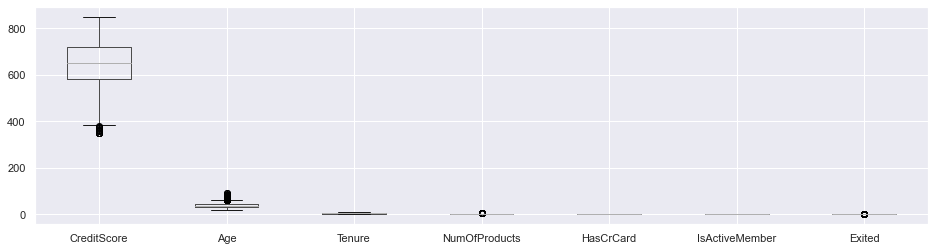

```python
df2=df1.drop(['Balance', 'EstimatedSalary'], axis=1)
df2.boxplot(figsize=(16,4))
```

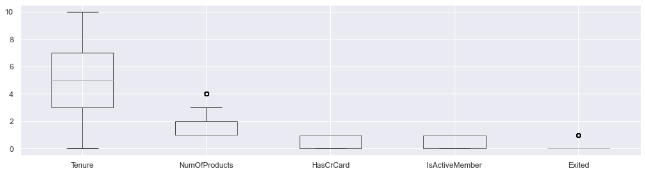

```python
df3=df2.drop(['CreditScore', 'Age'], axis=1)
df3.boxplot(figsize=(16,4))
```

### Insights:

```python
features=['NumOfProducts', 'Balance', 'Exited']
for i in features:
    print(df1[i].value_counts())
```

```
1    5084
2    4590
3     266
4      60
Name: NumOfProducts, dtype: int64
0.00         3617
105473.74       2
130170.82       2
113063.83       1
80242.37        1
             ...
183555.24       1
137648.41       1
112689.95       1
115465.28       1
74681.90        1
Name: Balance, Length: 6382, dtype: int64
0    7963
1    2037
Name: Exited, dtype: int64
```

`36% have 'Balance' = 0. New category variable can be created as has a balance > 0 or not.`

### Crosstab tables and plots

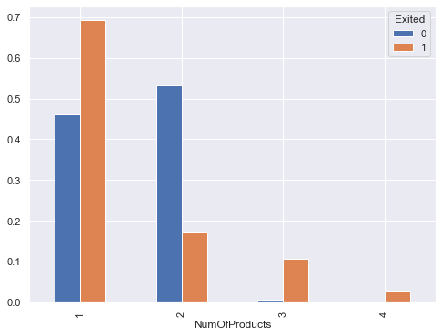

```python
plt.rcParams['figure.figsize'] = (8, 6)
pd.crosstab(df1.NumOfProducts, df1.Exited, normalize='columns').plot(kind='bar');
```

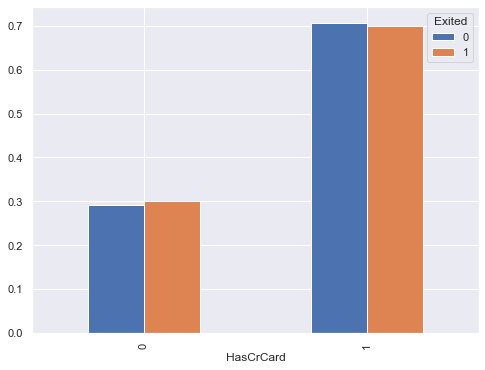

```python
plt.rcParams['figure.figsize'] = (8, 6)
pd.crosstab(df1.HasCrCard, df1.Exited, normalize='columns').plot(kind='bar');
```

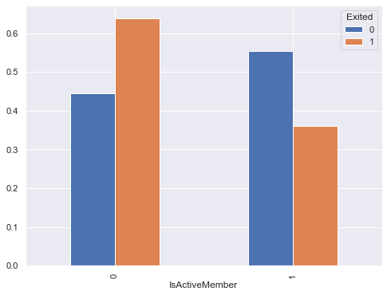

```python
plt.rcParams['figure.figsize'] = (8, 6)
pd.crosstab(df1.IsActiveMember, df1.Exited, normalize='columns').plot(kind='bar');
```

```python
df1['Balance_Cat'] = df1['Balance'].apply(lambda x: 1 if x>0 else 0)
df1.head(3)
```

|  | CreditScore | Geography | Gender | Age | Tenure | Balance | NumOfProducts | HasCrCard | IsActiveMember | EstimatedSalary | Exited | Balance_Cat |
| --- | --- | --- | --- | --- | --- | --- | --- | --- | --- | --- | --- | --- |
| 0 | 619 | France | Female | 42 | 2 | 0.00 | 1 | 1 | 1 | 101348.88 | 1 | 0 |
| 1 | 608 | Spain | Female | 41 | 1 | 83807.86 | 1 | 0 | 1 | 112542.58 | 0 | 1 |
| 2 | 502 | France | Female | 42 | 8 | 159660.80 | 3 | 1 | 0 | 113931.57 | 1 | 1 |

```python
df1['NumOfProducts'].value_counts(normalize=True)
```

```
1    0.5084
2    0.4590
3    0.0266
4    0.0060
Name: NumOfProducts, dtype: float64
```

`Only 3.2% have 3 and 4 NumOfproducts: below merged into single category.`

```python
df4=df1.copy()

df4['NumOfProducts'] = np.where(df4['NumOfProducts'] > 2, 3, df4['NumOfProducts'])
df4['NumOfProducts'].value_counts(normalize=True)
```

```
1    0.5084
2    0.4590
3    0.0326
Name: NumOfProducts, dtype: float64
```

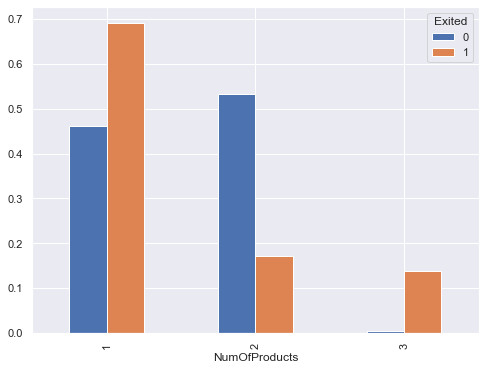

```python
plt.rcParams['figure.figsize'] = (8, 6)
pd.crosstab(df4.NumOfProducts, df4.Exited, normalize='columns').plot(kind='bar');
```

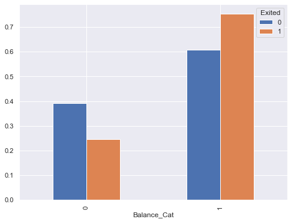

```python
plt.rcParams['figure.figsize'] = (8, 6)
pd.crosstab(df4.Balance_Cat, df4.Exited, normalize='columns').plot(kind='bar');
```

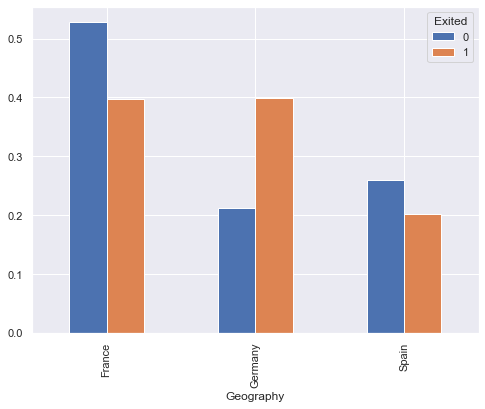

```python
plt.rcParams['figure.figsize'] = (8, 6)
pd.crosstab(df4.Geography, df4.Exited, normalize='columns').plot(kind='bar');
```

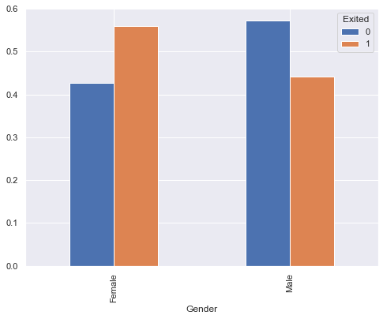

```python
plt.rcParams['figure.figsize'] = (8, 6)
pd.crosstab(df4.Gender, df4.Exited, normalize='columns').plot(kind='bar');
```

```python
df4.head(3)
```

|  | CreditScore | Geography | Gender | Age | Tenure | Balance | NumOfProducts | HasCrCard | IsActiveMember | EstimatedSalary | Exited | Balance_Cat |
| --- | --- | --- | --- | --- | --- | --- | --- | --- | --- | --- | --- | --- |
| 0 | 619 | France | Female | 42 | 2 | 0.00 | 1 | 1 | 1 | 101348.88 | 1 | 0 |
| 1 | 608 | Spain | Female | 41 | 1 | 83807.86 | 1 | 0 | 1 | 112542.58 | 0 | 1 |
| 2 | 502 | France | Female | 42 | 8 | 159660.80 | 3 | 1 | 0 | 113931.57 | 1 | 1 |

```python
df4.groupby('Exited').mean()
```

| Exited | CreditScore | Age | Tenure | Balance | NumOfProducts | HasCrCard | IsActiveMember | EstimatedSalary | Balance_Cat |
| --- | --- | --- | --- | --- | --- | --- | --- | --- | --- |
| 0 | 651.853196 | 37.408389 | 5.033279 | 72745.296779 | 1.544267 | 0.707146 | 0.554565 | 99738.391772 | 0.608565 |
| 1 | 645.351497 | 44.837997 | 4.932744 | 91108.539337 | 1.445754 | 0.699067 | 0.360825 | 101465.677531 | 0.754541 |

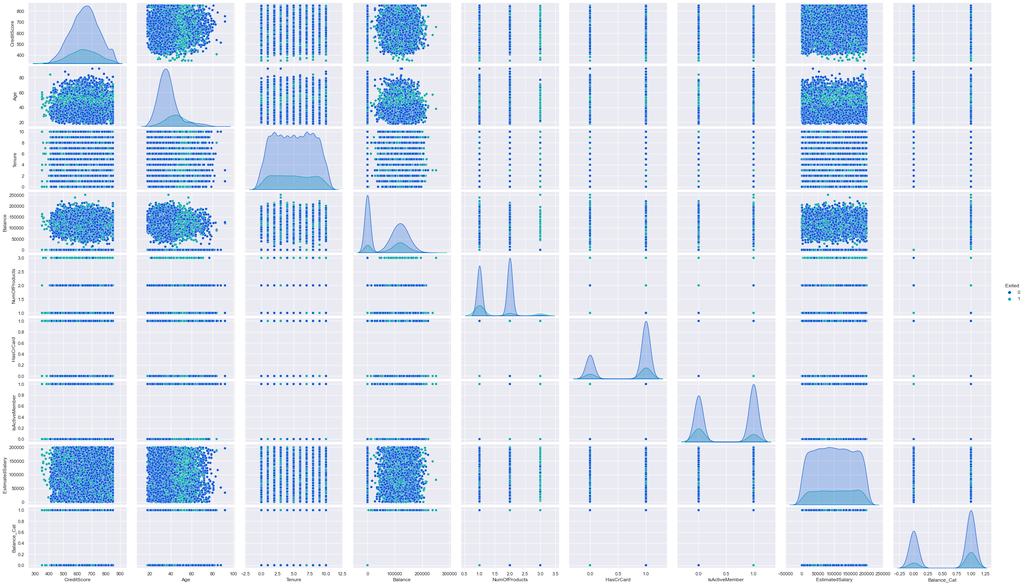

```python
sns.pairplot(df4, hue='Exited', height=2.2, aspect=1.7, palette='winter')
```

### Insights:

- Observations from crosstabs, concentarteing on exited people:
  - 'HasCreditCard' have nearly equal distribution of exited;
  - People that are not active members tend to exit more;
  - Almost all exited with 'NumOfProducts' under category 3, and more with 1 product. NumOfProducts = 2 seems to be the best to keep customers;
  - People with no 'Balance' seem exit less than group with some 'Balance';
  - People from Germany seem to exit more than people from France and Spain;
  - Females tend to exit more than males;
- People with higher age (on average) are exiting more than younger people.
- People with higher 'Balance' and 'Estimatedsalary' (on average) are exiting more.

### Outliers removal for 'Age'

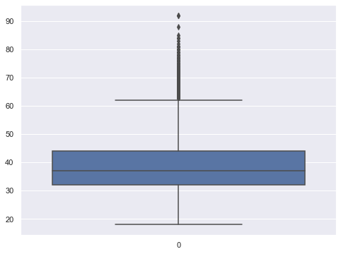

```python
sns.boxplot(data=df4['Age'])
```

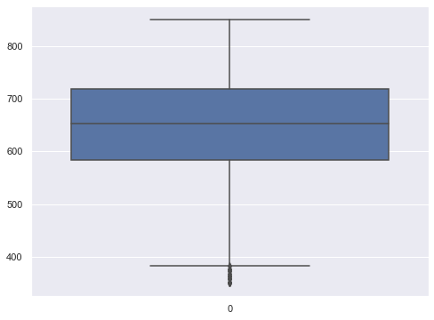

```python
sns.boxplot(data=df4['CreditScore'])
```

### Remove outliers using KNN

```python
Q1 = df4['Age'].quantile(q=0.25)
Q3 = df4['Age'].quantile(q=0.75)
IQR = Q3 - Q1
IQR
```

```
12.0
```

```python
outliers_ag = np.where((df4['Age'] < (Q1 - 1.5 * IQR)) | (df4['Age'] > (Q3 + 1.5 * IQR)))
print(f'length of Age outliers is: {len(outliers_ag[0])/len(df4)*100}%')
```

```
length of Age outliers is: 3.5900000000000003%
```

```python
from sklearn.neighbors import LocalOutlierFactor

clf = LocalOutlierFactor(n_neighbors=500)

array=np.array(df4['Age']).reshape(-1,1)

df4['outlier'] = clf.fit_predict(array)

print(df4[df4['outlier'] == -1].shape)
```

```
(195, 13)
```

```python
df4['outlier'].value_counts()
```

```
 1    9805
-1     195
Name: outlier, dtype: int64
```

```python
print(f'Age outliers will be replaced with {Q3+1.5*IQR} yers old (the life expectancy for the analysis :)')
```

```
Age outliers will be replaced with 62.0 yers old (the life expectancy for the analysis :)
```

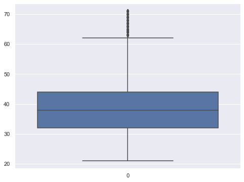

```python
df5 = df4.copy()

new_vals=Q3+1.5*IQR

df5['Age'] = np.where(df5['outlier'] ==-1, new_vals, df5['Age'])

df5.drop(['outlier'], axis=1, inplace=True)
sns.boxplot(data=df5['Age'])
```

`Log Transform to further normalize the 'Age'.`

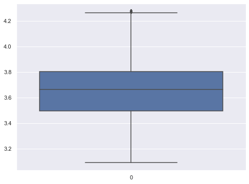

```python
df6=df5.copy()

df6['Age_log']=np.log1p(df6['Age'])
df6.drop(['Age'], axis=1, inplace=True)

sns.boxplot(data=df6['Age_log'])
```

### Feature and target set preparation and Split the data for training and testing sets

```python
df6.info()
```

```
<class 'pandas.core.frame.DataFrame'>
RangeIndex: 10000 entries, 0 to 9999
Data columns (total 12 columns):
 #   Column           Non-Null Count  Dtype
---  ------           --------------  -----
 0   CreditScore      10000 non-null  int64
 1   Geography        10000 non-null  object
 2   Gender           10000 non-null  object
 3   Tenure           10000 non-null  int64
 4   Balance          10000 non-null  float64
 5   NumOfProducts    10000 non-null  int64
 6   HasCrCard        10000 non-null  int64
 7   IsActiveMember   10000 non-null  int64
 8   EstimatedSalary  10000 non-null  float64
 9   Exited           10000 non-null  int64
 10  Balance_Cat      10000 non-null  int64
 11  Age_log          10000 non-null  float64
dtypes: float64(3), int64(7), object(2)
memory usage: 937.6+ KB
```

`Encoding categorical varibales.`

```python
onehotcols=['Geography', 'Gender']
for i in onehotcols:
    print(df4[i].value_counts(normalize=True))
```

```
France     0.5014
Germany    0.2509
Spain      0.2477
Name: Geography, dtype: float64
Male      0.5457
Female    0.4543
Name: Gender, dtype: float64
```

```python
df7 = pd.get_dummies(df6, columns=onehotcols)
df7.head()
```

|  | CreditScore | Tenure | Balance | NumOfProducts | HasCrCard | IsActiveMember | EstimatedSalary | Exited | Balance_Cat | Age_log | Geography_France | Geography_Germany | Geography_Spain | Gender_Female | Gender_Male |
| --- | --- | --- | --- | --- | --- | --- | --- | --- | --- | --- | --- | --- | --- | --- | --- |
| 0 | 619 | 2 | 0.00 | 1 | 1 | 1 | 101348.88 | 1 | 0 | 3.761200 | 1 | 0 | 0 | 1 | 0 |
| 1 | 608 | 1 | 83807.86 | 1 | 0 | 1 | 112542.58 | 0 | 1 | 3.737670 | 0 | 0 | 1 | 1 | 0 |
| 2 | 502 | 8 | 159660.80 | 3 | 1 | 0 | 113931.57 | 1 | 1 | 3.761200 | 1 | 0 | 0 | 1 | 0 |
| 3 | 699 | 1 | 0.00 | 2 | 0 | 0 | 93826.63 | 0 | 0 | 3.688879 | 1 | 0 | 0 | 1 | 0 |
| 4 | 850 | 2 | 125510.82 | 1 | 1 | 1 | 79084.10 | 0 | 1 | 3.784190 | 0 | 0 | 1 | 1 | 0 |

```python
df7.info()
```

```
<class 'pandas.core.frame.DataFrame'>
RangeIndex: 10000 entries, 0 to 9999
Data columns (total 15 columns):
 #   Column             Non-Null Count  Dtype
---  ------             --------------  -----
 0   CreditScore        10000 non-null  int64
 1   Tenure             10000 non-null  int64
 2   Balance            10000 non-null  float64
 3   NumOfProducts      10000 non-null  int64
 4   HasCrCard          10000 non-null  int64
 5   IsActiveMember     10000 non-null  int64
 6   EstimatedSalary    10000 non-null  float64
 7   Exited             10000 non-null  int64
 8   Balance_Cat        10000 non-null  int64
 9   Age_log            10000 non-null  float64
 10  Geography_France   10000 non-null  uint8
 11  Geography_Germany  10000 non-null  uint8
 12  Geography_Spain    10000 non-null  uint8
 13  Gender_Female      10000 non-null  uint8
 14  Gender_Male        10000 non-null  uint8
dtypes: float64(3), int64(7), uint8(5)
memory usage: 830.2 KB
```

#### 'Exited' is the target variable (y), when all others are features for modeling (X)

```python
X = df7.drop(['Exited'], axis=1)
y = df7['Exited'].values.reshape(-1, 1)
```

```python
X_train, X_test, y_train, y_test = train_test_split(X, y, test_size = 0.25, stratify=y, random_state = 772)

print(X_train.shape, y_train.shape)
print(X_test.shape, y_test.shape)
```

```
(7500, 14) (7500, 1)
(2500, 14) (2500, 1)
```

```python
test_data=pd.DataFrame(y_test)
test_data = test_data.rename(columns={0:'test_result'})
print('class weights by percent: ', test_data['test_result'].value_counts(normalize=True)*100)
test_data['test_result'].value_counts()
```

```
class weights by percent:  0    79.64
1    20.36
Name: test_result, dtype: float64
```

```
0    1991
1     509
Name: test_result, dtype: int64
```

`From the test set, 509 people are exited and will be analyzed on a confusion matrix.`

### Normalization of train and test sets (scaling)

```python
from sklearn.preprocessing import MinMaxScaler

scale = MinMaxScaler()

scale
```

```
MinMaxScaler()
```

```python
X_scaler=scale.fit(X_train)
```

```python
X_train_scaled=X_scaler.transform(X_train)
X_test_scaled=X_scaler.transform(X_test)
```

```python
print(X_train_scaled.shape)
print(X_test_scaled.shape)
print(y_train.shape)
print(y_test.shape)
```

```
(7500, 14)
(2500, 14)
(7500, 1)
(2500, 1)
```

## DNN Modeling

- To handle highly-unbalanced class of 'Exited' people, class_weight hyperparameter was used in modeling. This can be adjusted with a weight up to 0.9 for the class of interest to obtain high recall scores. Although this will drop the precision. So that, building two separate models for:
  - Higher recall score and lower precision, assigning weight of 0.85 to the class of interest.
  - Lower recall and higher precision, assigning weight of 0.8 to the class of interest, which reflects more actual data distribution of only 20% exited people.
- These models can be chosen per business needs: predict most of the exiting people, when suspecting many non-related or lose some of the exiting on predictions, but not suspecting as many non-related.

### Model #1: For Higher recall (*with Lower presicion*)

#### Initialize and build the model

```python
model = Sequential()

model.add(Dense(20, input_shape = (14,), activation = 'relu'))
model.add(Dense(20, activation = 'relu'))
model.add(Dense(1, activation = 'sigmoid'))

optimizer = optimizers.Adam(lr = 0.001)

model.compile(optimizer = optimizer, loss = 'binary_crossentropy', metrics=['accuracy'])

model.summary()
```

```
Model: "sequential_7"
_________________________________________________________________
Layer (type)                 Output Shape              Param #
=================================================================
dense_26 (Dense)             (None, 20)                300
_________________________________________________________________
dense_27 (Dense)             (None, 20)                420
_________________________________________________________________
dense_28 (Dense)             (None, 1)                 21
=================================================================
Total params: 741
Trainable params: 741
Non-trainable params: 0
_________________________________________________________________
```

### Identified points of improvement that were optimized:

- Number of hidden layers (2)
- Number of nodes: 20 per each layer
- Laerning rate: 0.001 seems to be optimal (among many others i have tried)
- Activation functions: 'relu' and 'sigmoid' for the last. Because it is binary classifiction, model can work without the activation function in the output layer, although 'sigmoid' improved the model scores.

#### Model training

```python
# Fit the model and cath the history to find out
# optimal number of epoches in order not to waste computaional resources.

history=model.fit(
        X_train_scaled,
        y_train,
        batch_size = 1000,
        epochs = 100,
        class_weight={0:0.15, 1:0.85},
        shuffle=True,
        validation_split = 0.2,
        verbose=False)

hist  = pd.DataFrame(history.history)
hist['epoch'] = history.epoch

hist.head()
```

|  | loss | accuracy | val_loss | val_accuracy | epoch |
| --- | --- | --- | --- | --- | --- |
| 0 | 0.201217 | 0.459000 | 0.201165 | 0.382000 | 0 |
| 1 | 0.198538 | 0.331000 | 0.199153 | 0.286667 | 1 |
| 2 | 0.196889 | 0.258833 | 0.197586 | 0.238000 | 2 |
| 3 | 0.195555 | 0.235000 | 0.196249 | 0.230000 | 3 |
| 4 | 0.194366 | 0.229333 | 0.194932 | 0.235333 | 4 |

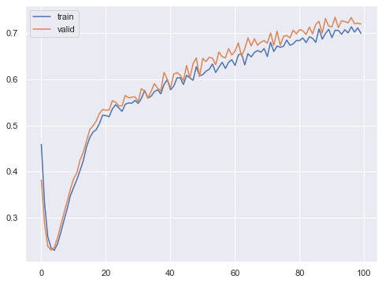

```python
#Plotting the scores vs. epoches to confirm model converge

plt.plot(hist['accuracy'])
plt.plot(hist['val_accuracy'])
plt.legend(("train" , "valid") , loc =0)
```

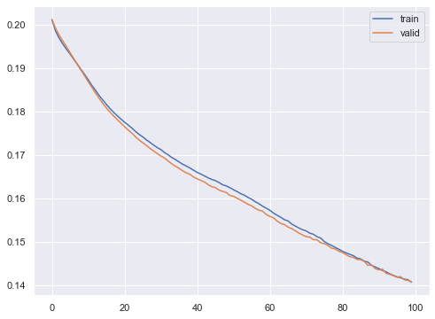

```python
plt.plot(hist['loss'])
plt.plot(hist['val_loss'])
plt.legend(("train" , "valid") , loc =0)
```

`100 epoches seems to be optimal`

```python
# Final model results
hist[-1:]
```

|  | loss | accuracy | val_loss | val_accuracy | epoch |
| --- | --- | --- | --- | --- | --- |
| 99 | 0.14062 | 0.699667 | 0.140715 | 0.72 | 99 |

### Predicting the results using 0.5 as a threshold and accuracy score

```python
Y_pred_cls = model.predict_classes(X_test_scaled, batch_size=1000, verbose=0)
Y_pred_cls = (Y_pred_cls > 0.5)

print('Accuracy Model (Dropout): '+ str(model.evaluate(X_test_scaled, y_test)[1]))

print('Recall_score: ' + str(round(recall_score(y_test,Y_pred_cls), 3)))
print('Precision_score: ' + str(round(precision_score(y_test, Y_pred_cls), 3)))
print('F-score: ' + str(round(f1_score(y_test,Y_pred_cls), 3)))
```

```
Accuracy Model (Dropout): 0.7204
Recall_score: 0.845
Precision_score: 0.41
F-score: 0.552
```

### Confusion matrix

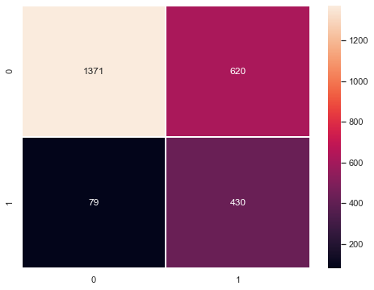

```python
cm=confusion_matrix(y_test, Y_pred_cls)

sns.heatmap(cm, linewidths=1, annot=True, fmt='g')
```

### Model #2: For higher precision (*with Lower recall*)

```python
model = Sequential()

model.add(Dense(50, input_shape = (14,), activation = 'relu'))
model.add(Dense(50, activation = 'relu'))
model.add(Dense(1, activation = 'sigmoid'))

optimizer = optimizers.Adam(lr = 0.001)

model.compile(optimizer = optimizer, loss = 'binary_crossentropy', metrics=['accuracy'])

model.summary()
```

```
Model: "sequential_8"
_________________________________________________________________
Layer (type)                 Output Shape              Param #
=================================================================
dense_29 (Dense)             (None, 50)                750
_________________________________________________________________
dense_30 (Dense)             (None, 50)                2550
_________________________________________________________________
dense_31 (Dense)             (None, 1)                 51
=================================================================
Total params: 3,351
Trainable params: 3,351
Non-trainable params: 0
_________________________________________________________________
```

### Identified points of improvement that were optimized:

- Number of hidden layers (2)
- Number of nodes: 50 per each layer
- Laerning rate: 0.001 seems to be optimal (among many others i have tried)
- Activation functions: 'relu' and 'sigmoid' for the last. Because it is binary classifiction, model can work without the activation function in the output layer, although 'sigmoid' improved the model scores.

```python
# Fit the model, training

history=model.fit(
        X_train_scaled,
        y_train,
        batch_size = 1000,
        epochs = 52,
        class_weight={0:0.2, 1:0.8},
        shuffle=True,
        validation_split = 0.2,
        verbose=False)

hist  = pd.DataFrame(history.history)
hist['epoch'] = history.epoch

hist.head()
```

|  | loss | accuracy | val_loss | val_accuracy | epoch |
| --- | --- | --- | --- | --- | --- |
| 0 | 0.224156 | 0.557000 | 0.222777 | 0.446000 | 0 |
| 1 | 0.219137 | 0.477500 | 0.218868 | 0.506667 | 1 |
| 2 | 0.215304 | 0.536500 | 0.215176 | 0.591333 | 2 |
| 3 | 0.211940 | 0.604333 | 0.211639 | 0.628000 | 3 |
| 4 | 0.208700 | 0.635667 | 0.208341 | 0.658000 | 4 |

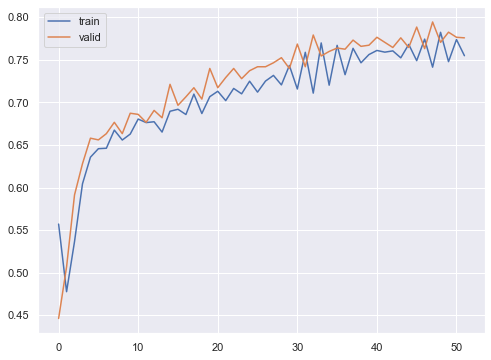

```python
plt.plot(hist['accuracy'])
plt.plot(hist['val_accuracy'])
plt.legend(("train" , "valid") , loc =0)
```

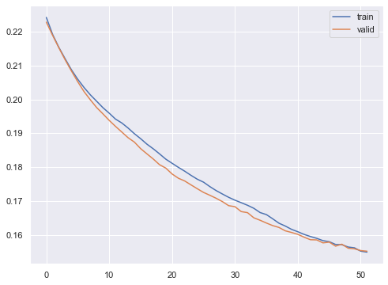

```python
plt.plot(hist['loss'])
plt.plot(hist['val_loss'])
plt.legend(("train" , "valid") , loc =0)
```

`52 epoches seems to be optimal`

```python
# Final model results
hist[-1:]
```

|  | loss | accuracy | val_loss | val_accuracy | epoch |
| --- | --- | --- | --- | --- | --- |
| 51 | 0.154994 | 0.755 | 0.155265 | 0.776 | 51 |

### Predicting the results using 0.5 as a threshold and accuracy score

```python
Y_pred_cls = model.predict_classes(X_test_scaled, batch_size=1000, verbose=0)
Y_pred_cls = (Y_pred_cls > 0.5)

print('Accuracy Model (Dropout): '+ str(model.evaluate(X_test_scaled, y_test)[1]))

print('Recall_score: ' + str(round(recall_score(y_test,Y_pred_cls), 3)))
print('Precision_score: ' + str(round(precision_score(y_test, Y_pred_cls), 3)))
print('F-score: ' + str(round(f1_score(y_test,Y_pred_cls), 3)))
```

```
Accuracy Model (Dropout): 0.7704
Recall_score: 0.772
Precision_score: 0.462
F-score: 0.578
```

### Confusion matrix

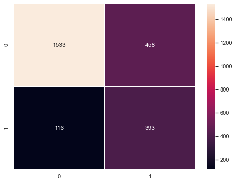

```python
cm2=confusion_matrix(y_test, Y_pred_cls)
sns.heatmap(cm2, linewidths=1, annot=True, fmt='g')
```

### Conclusions:

1. First model resulted in Recall score of 84.5% with only 79 FN people (from 509) where model 'lost' them as exiting. The model precsion score is very low, only 41%, and 620 FP people (from 1991) where model 'thinks' they will exit , but they will not.
2. Second model resulted in Recall score of 77% with 116 FN people (from 509) where model 'lost' them as exiting. The model precsion score is somewhat higher, although still only 46%, and 458 FP people (from 1991) where model 'thinks' they will exit , but they will not.
3. Precsion can be adjusted by more equally balancing class_weight hyperparameter when training the models.
   - Business direction should identify which modeling direction to choose and what precison-recall scores are of interest.